# S20 PSTAT126 Final Project

Karen Zhao

6/6/2020

# Regression Analysis on U.S. Life Expectancy

## 1. Introduction

This project focuses on studying the prediction of life expectancy in the U.S. states based on the dataset ‘state.x77’ in R library, which is derived from the U.S. Department of Commerce,Bureau of the Census (1977) Statistical Abstract of the United States. We will examine the effects of the following 7 variables on life expectancy: population, income, illiteracy, murder rate(Murder), high school graduate rate (HS Grad), land area, and mean number of days with minimum temperature below freezing (Frost). We find that ‘Murder’, ‘HS Grad’, ‘Frost’, and “Population’ are the most related predictors.

```r
dat=as.data.frame(state.x77)
attach(dat)
names(dat)
```

```
## [1] "Population" "Income"     "Illiteracy" "Life Exp"   "Murder"
## [6] "HS Grad"    "Frost"      "Area"
```

## 2. Questions of Interest

Can we predict life expectancy of a region given its population, income, illiteracy, murder rate (Murder), high school graduate percent (HS Grad), land area, and mean number of days with minimum temperature below freezing (Frost) as predictors?

## 3. Regression Method

We will approach this question first by applying stepwise and best subsets regression on the 7 potential predictors to determine the best model. Then we will check LINE conditions on this model using residual analysis. If any of the assumptions are not met, we will transform the data and check LINE conditions for the new model. After fitting the model with transformed data, we will interpret our model and summarize our findings.

## 4. Regression Analysis, Results and Interpretation

### Variable Selection

First, we look at the scatterplot matrix to gain some insight on the relationships between the variables in the data. From the scatterplot below, we can tell that there are some predictors like ‘Murder’ seems to be strongly related to ‘Life Expectancy’. Others like ‘Area’ and ‘Income’ seem to be moderately or weakly related.

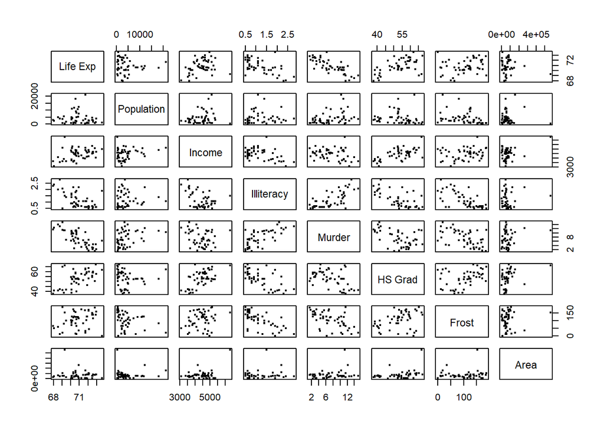

```r
pairs(dat[c(4,1,2,3,5,6,7,8)], cex=0.4) #scatterplot matrix
```

```r
cor(dat)
```

```
##             Population     Income  Illiteracy    Life Exp     Murder
## Population  1.00000000  0.2082276  0.10762237 -0.06805195  0.3436428
## Income      0.20822756  1.0000000 -0.43707519  0.34025534 -0.2300776
## Illiteracy  0.10762237 -0.4370752  1.00000000 -0.58847793  0.7029752
## Life Exp   -0.06805195  0.3402553 -0.58847793  1.00000000 -0.7808458
## Murder      0.34364275 -0.2300776  0.70297520 -0.78084575  1.0000000
## HS Grad    -0.09848975  0.6199323 -0.65718861  0.58221620 -0.4879710
## Frost      -0.33215245  0.2262822 -0.67194697  0.26206801 -0.5388834
## Area        0.02254384  0.3633154  0.07726113 -0.10733194  0.2283902
##                HS Grad      Frost        Area
## Population -0.09848975 -0.3321525  0.02254384
## Income      0.61993232  0.2262822  0.36331544
## Illiteracy -0.65718861 -0.6719470  0.07726113
## Life Exp    0.58221620  0.2620680 -0.10733194
## Murder     -0.48797102 -0.5388834  0.22839021
## HS Grad     1.00000000  0.3667797  0.33354187
## Frost       0.36677970  1.0000000  0.05922910
## Area        0.33354187  0.0592291  1.00000000
```

Secondly, we perform variable selection using stepwise regression, including AIC and partial F test, and the best subsets regression to determine the predictors. The results of our AIC test, partial F test, and adjusted R2 criterion chooses four predictors: “Murder”, “HS Grad”, “Frost”, and “Population” . The Mallows’ Cp criterion gives similar result except excluding the fourth predictor “Population”. Therefore, We decide our model to be `Life Exp` ~ Murder + `HS Grad` + Frost + Population.

```r
# Stepwise regression using AIC
mod0=lm(`Life Exp`~1)
mod.all = lm(`Life Exp`~., data=dat) # including all predictors in lm()
step(mod0, scope = list(lower = mod0, upper = mod.all))
```

```
## Start:  AIC=30.44
## `Life Exp` ~ 1
##
##              Df Sum of Sq    RSS     AIC
## + Murder      1    53.838 34.461 -14.609
## + Illiteracy  1    30.578 57.721  11.179
## + `HS Grad`   1    29.931 58.368  11.737
## + Income      1    10.223 78.076  26.283
## + Frost       1     6.064 82.235  28.878
## <none>                    88.299  30.435
## + Area        1     1.017 87.282  31.856
## + Population  1     0.409 87.890  32.203
##
## Step:  AIC=-14.61
## `Life Exp` ~ Murder
##
##              Df Sum of Sq    RSS     AIC
## + `HS Grad`   1     4.691 29.770 -19.925
## + Population  1     4.016 30.445 -18.805
## + Frost       1     3.135 31.327 -17.378
## + Income      1     2.405 32.057 -16.226
## <none>                    34.461 -14.609
## + Area        1     0.470 33.992 -13.295
## + Illiteracy  1     0.273 34.188 -13.007
## - Murder      1    53.838 88.299  30.435
##
## Step:  AIC=-19.93
## `Life Exp` ~ Murder + `HS Grad`
##
##              Df Sum of Sq    RSS     AIC
## + Frost       1    4.3987 25.372 -25.920
## + Population  1    3.3405 26.430 -23.877
## <none>                    29.770 -19.925
## + Illiteracy  1    0.4419 29.328 -18.673
## + Area        1    0.2775 29.493 -18.394
## + Income      1    0.1022 29.668 -18.097
## - `HS Grad`   1    4.6910 34.461 -14.609
## - Murder      1   28.5974 58.368  11.737
##
## Step:  AIC=-25.92
```

[output cut: 9 more lines]

```
## - `HS Grad`   1     5.955 31.327 -17.378
## - Murder      1    32.756 58.128  13.531
##
## Step:  AIC=-28.16
## `Life Exp` ~ Murder + `HS Grad` + Frost + Population
##
##              Df Sum of Sq    RSS     AIC
## <none>                    23.308 -28.161
## + Income      1     0.006 23.302 -26.174
## + Illiteracy  1     0.004 23.304 -26.170
## + Area        1     0.001 23.307 -26.163
## - Population  1     2.064 25.372 -25.920
## - Frost       1     3.122 26.430 -23.877
## - `HS Grad`   1     5.112 28.420 -20.246
## - Murder      1    34.816 58.124  15.528
```

```
##
## Call:
## lm(formula = `Life Exp` ~ Murder + `HS Grad` + Frost + Population)
##
## Coefficients:
## (Intercept)       Murder    `HS Grad`        Frost   Population
##   7.103e+01   -3.001e-01    4.658e-02   -5.943e-03    5.014e-05
```

```r
mod.AIC = lm(`Life Exp` ~ Murder + `HS Grad` + Frost + Population, data=dat)

# Stepwise regression using F-test
mod0=lm(`Life Exp`~1)
add1(mod0, ~.+Population+Income+Illiteracy+Murder+`HS Grad`+Frost+Area, test = 'F')
```

|  | Df | Sum of Sq | RSS | AIC | F value | Pr(>F) |
| --- | --- | --- | --- | --- | --- | --- |
|  | NA | NA | 88.29900 | 30.43529 | NA | NA |
| Population | 1 | 0.4089187 | 87.89008 | 32.20320 | 0.2233255 | 6.386594e-01 |
| Income | 1 | 10.2227018 | 78.07630 | 26.28318 | 6.2847456 | 1.561728e-02 |
| Illiteracy | 1 | 30.5784979 | 57.72050 | 11.17947 | 25.4288822 | 6.969250e-06 |
| Murder | 1 | 53.8376753 | 34.46133 | -14.60926 | 74.9886515 | 2.260070e-11 |
| `HS Grad` | 1 | 29.9312167 | 58.36779 | 11.73706 | 24.6145780 | 9.196096e-06 |
| Frost | 1 | 6.0643439 | 82.23466 | 28.87769 | 3.5397302 | 6.598740e-02 |
| Area | 1 | 1.0172172 | 87.28178 | 31.85594 | 0.5594114 | 4.581464e-01 |

```r
#choose Murder, which has the smallest p-value or largest F-statistic
mod1 = update(mod0, ~.+Murder)
add1(mod1, ~.+Population+Income+Illiteracy+`HS Grad`+Frost+Area, test = 'F')
```

|  | Df | Sum of Sq | RSS | AIC | F value | Pr(>F) |
| --- | --- | --- | --- | --- | --- | --- |
|  | NA | NA | 34.46133 | -14.60926 | NA | NA |
| Population | 1 | 4.0161229 | 30.44520 | -18.80473 | 6.1999183 | 0.016369405 |
| Income | 1 | 2.4047425 | 32.05658 | -16.22602 | 3.5257311 | 0.066636192 |
| Illiteracy | 1 | 0.2732293 | 34.18810 | -13.00727 | 0.3756212 | 0.542910441 |
| `HS Grad` | 1 | 4.6909709 | 29.77036 | -19.92549 | 7.4058784 | 0.009088366 |
| Frost | 1 | 3.1346230 | 31.32670 | -17.37761 | 4.7029296 | 0.035205232 |
| Area | 1 | 0.4696851 | 33.99164 | -13.29542 | 0.6494303 | 0.424375130 |

```r
#choose HS Grad, which has the smallest p-value or largest F-statistic
mod2 = update(mod1, ~.+`HS Grad`)
#check if Murder is still significant after adding HS Grad
summary(mod2)
```

```
##
## Call:
## lm(formula = `Life Exp` ~ Murder + `HS Grad`)
##
## Residuals:
##      Min       1Q   Median       3Q      Max
## -1.66758 -0.41801  0.05602  0.55913  2.05625
##
## Coefficients:
##             Estimate Std. Error t value Pr(>|t|)
## (Intercept) 70.29708    1.01567  69.213  < 2e-16 ***
## Murder      -0.23709    0.03529  -6.719 2.18e-08 ***
## `HS Grad`    0.04389    0.01613   2.721  0.00909 **
## ---
## Signif. codes:  0 '***' 0.001 '**' 0.01 '*' 0.05 '.' 0.1 ' ' 1
##
## Residual standard error: 0.7959 on 47 degrees of freedom
## Multiple R-squared:  0.6628, Adjusted R-squared:  0.6485
## F-statistic:  46.2 on 2 and 47 DF,  p-value: 8.016e-12
```

```r
#both predictors have very small p-value: significant
add1(mod2, ~.+Population+Income+Illiteracy+Frost+Area, test = 'F')
```

|  | Df | Sum of Sq | RSS | AIC | F value | Pr(>F) |
| --- | --- | --- | --- | --- | --- | --- |
|  | NA | NA | 29.77036 | -19.92549 | NA | NA |
| Population | 1 | 3.3405318 | 26.42982 | -23.87650 | 5.8140555 | 0.019949256 |
| Income | 1 | 0.1022013 | 29.66815 | -18.09744 | 0.1584615 | 0.692418445 |
| Illiteracy | 1 | 0.4418894 | 29.32847 | -18.67322 | 0.6930780 | 0.409420903 |
| Frost | 1 | 4.3987308 | 25.37162 | -25.91958 | 7.9751146 | 0.006987727 |
| Area | 1 | 0.2775339 | 29.49282 | -18.39381 | 0.4328701 | 0.513863248 |

```r
#choose Frost, which has the smallest p-value or largest F-statistic
mod3 = update(mod2, ~.+Frost)
#check if Murder and HS Grad are still significant after adding Frost
summary(mod3)
```

```
##
## Call:
## lm(formula = `Life Exp` ~ Murder + `HS Grad` + Frost)
##
## Residuals:
##     Min      1Q  Median      3Q     Max
## -1.5015 -0.5391  0.1014  0.5921  1.2268
##
## Coefficients:
##              Estimate Std. Error t value Pr(>|t|)
## (Intercept) 71.036379   0.983262  72.246  < 2e-16 ***
## Murder      -0.283065   0.036731  -7.706 8.04e-10 ***
## `HS Grad`    0.049949   0.015201   3.286  0.00195 **
## Frost       -0.006912   0.002447  -2.824  0.00699 **
## ---
## Signif. codes:  0 '***' 0.001 '**' 0.01 '*' 0.05 '.' 0.1 ' ' 1
##
## Residual standard error: 0.7427 on 46 degrees of freedom
## Multiple R-squared:  0.7127, Adjusted R-squared:  0.6939
## F-statistic: 38.03 on 3 and 46 DF,  p-value: 1.634e-12
```

```r
#all predictors have very small p-value: significant
add1(mod3, ~.+Population+Income+Illiteracy+Area, test = 'F')
```

|  | Df | Sum of Sq | RSS | AIC | F value | Pr(>F) |
| --- | --- | --- | --- | --- | --- | --- |
|  | NA | NA | 25.37162 | -25.91958 | NA | NA |
| Population | 1 | 2.0635821 | 23.30804 | -28.16123 | 3.9840838 | 0.05200514 |
| Income | 1 | 0.1823242 | 25.18930 | -24.28018 | 0.3257172 | 0.57103101 |
| Illiteracy | 1 | 0.1718356 | 25.19979 | -24.25937 | 0.3068519 | 0.58236079 |
| Area | 1 | 0.0257280 | 25.34590 | -23.97031 | 0.0456784 | 0.83172689 |

```r
#choose Pop, which has the smallest p-value or largest F-statistic
mod4 = update(mod3, ~.+Population)
#check if Murder, HS Grad, and Frost are still significant after adding Pop
summary(mod4)
```

```
##
## Call:
## lm(formula = `Life Exp` ~ Murder + `HS Grad` + Frost + Population)
##
## Residuals:
##      Min       1Q   Median       3Q      Max
## -1.47095 -0.53464 -0.03701  0.57621  1.50683
##
## Coefficients:
##               Estimate Std. Error t value Pr(>|t|)
## (Intercept)  7.103e+01  9.529e-01  74.542  < 2e-16 ***
## Murder      -3.001e-01  3.661e-02  -8.199 1.77e-10 ***
## `HS Grad`    4.658e-02  1.483e-02   3.142  0.00297 **
## Frost       -5.943e-03  2.421e-03  -2.455  0.01802 *
## Population   5.014e-05  2.512e-05   1.996  0.05201 .
## ---
## Signif. codes:  0 '***' 0.001 '**' 0.01 '*' 0.05 '.' 0.1 ' ' 1
##
## Residual standard error: 0.7197 on 45 degrees of freedom
## Multiple R-squared:  0.736,  Adjusted R-squared:  0.7126
## F-statistic: 31.37 on 4 and 45 DF,  p-value: 1.696e-12
```

```r
#all predictors have very small p-value: significant
add1(mod4, ~.+Income+Illiteracy+Area, test = 'F')
```

|  | Df | Sum of Sq | RSS | AIC | F value | Pr(>F) |
| --- | --- | --- | --- | --- | --- | --- |
|  | NA | NA | 23.30804 | -28.16123 | NA | NA |
| Income | 1 | 0.0060582457 | 23.30198 | -26.17422 | 0.011439490 | 0.9153104 |
| Illiteracy | 1 | 0.0039220849 | 23.30412 | -26.16964 | 0.007405203 | 0.9318143 |
| Area | 1 | 0.0007900177 | 23.30725 | -26.16292 | 0.001491415 | 0.9693690 |

```r
#no more significant predictors, p-values > 0.15
#same model as what we found in AIC

#Best subset regression
library(leaps)
mod = regsubsets(cbind(Population, Income, Illiteracy, Murder, `HS Grad`, Frost, Area), `Life Exp`)
summary.mod = summary(mod)
summary.mod$which
```

```
##   (Intercept) Population Income Illiteracy Murder HS Grad Frost  Area
## 1        TRUE      FALSE  FALSE      FALSE   TRUE   FALSE FALSE FALSE
## 2        TRUE      FALSE  FALSE      FALSE   TRUE    TRUE FALSE FALSE
## 3        TRUE      FALSE  FALSE      FALSE   TRUE    TRUE  TRUE FALSE
## 4        TRUE       TRUE  FALSE      FALSE   TRUE    TRUE  TRUE FALSE
## 5        TRUE       TRUE   TRUE      FALSE   TRUE    TRUE  TRUE FALSE
## 6        TRUE       TRUE   TRUE       TRUE   TRUE    TRUE  TRUE FALSE
## 7        TRUE       TRUE   TRUE       TRUE   TRUE    TRUE  TRUE  TRUE
```

```r
names(summary.mod)
```

```
## [1] "which"  "rsq"    "rss"    "adjr2"  "cp"     "bic"    "outmat" "obj"
```

```r
summary.mod$adjr2
```

```
## [1] 0.6015893 0.6484991 0.6939230 0.7125690 0.7061129 0.6993268 0.6921823
```

```r
# from 3rd to 4th, increased almost 2%
# from 4th to fifith, dropping
# so we choose 4 predictors, look back at matrix, find that same as what we found in stepwise regression
summary.mod$cp
```

```
## [1] 16.126760  9.669894  3.739878  2.019659  4.008737  6.001959  8.000000
```

```r
# only C_p close to p is the third one, 3.74 close to p=4, three predictors
```

### Diagnostic Checks and Transformation

Thirdly, we check the LINE conditions for this model. We will not be checking the independence assumption, since we are not given data related to time order.

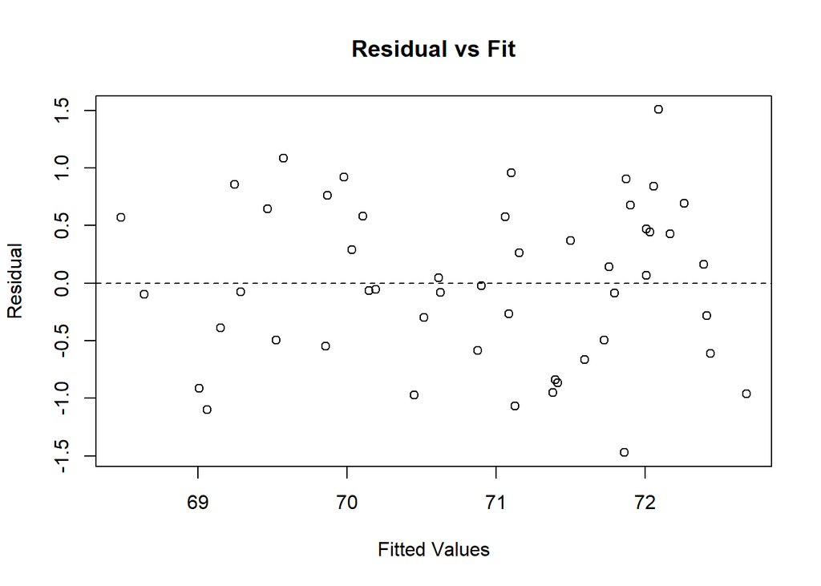

```r
# Residuals Analysis
yhat=mod.AIC$fitted.values
e=mod.AIC$residuals
plot(yhat, e, xlab = 'Fitted Values', ylab = 'Residual', main = 'Residual vs Fit')
abline(h = 0, lty = 2)
```

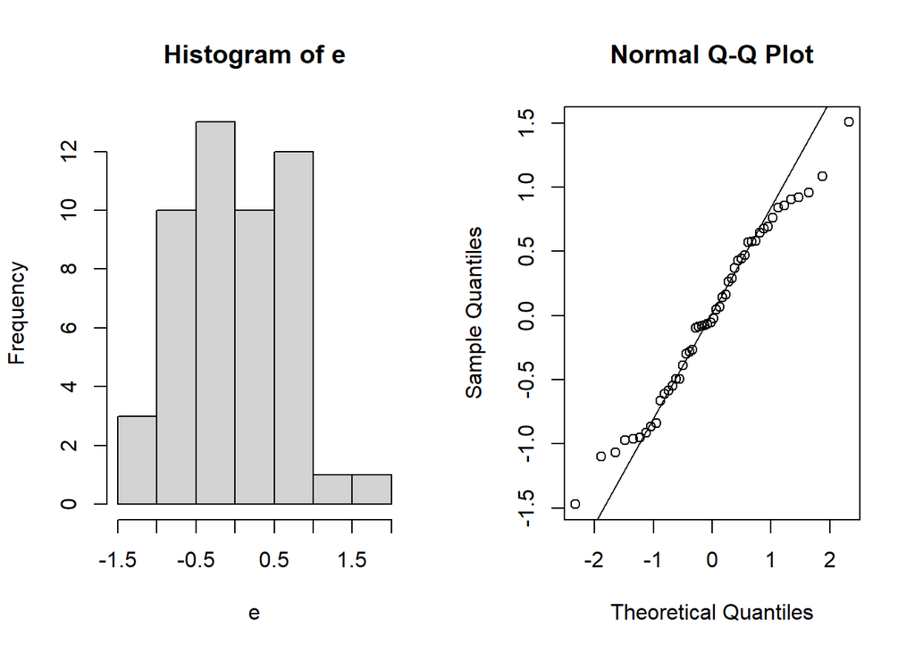

```r
par(mfrow=c(1,2))
hist(e)
qqnorm(e)
qqline(e)
```

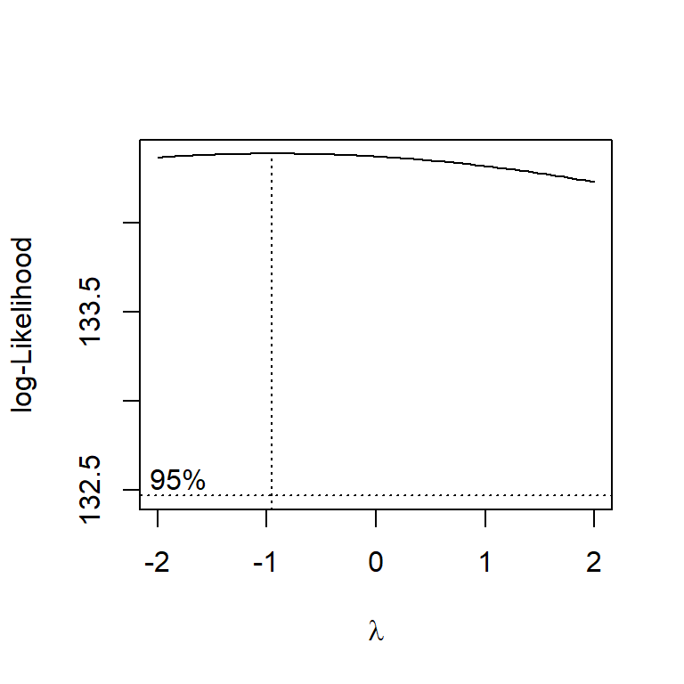

```r
library(MASS)
boxcox(`Life Exp`~Murder+`HS Grad`+Frost+Population, data=dat)
```

```r
# choose lambda -1

y <- 1/`Life Exp` #transform y
mod.trans <- lm(y ~ Murder + `HS Grad` + Frost + Population) #fit new model
```

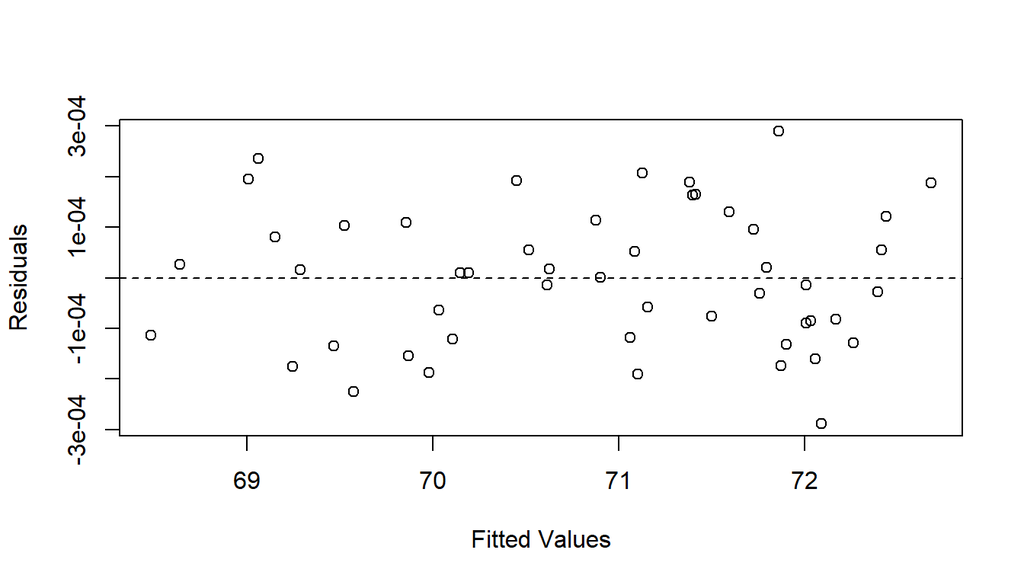

```r
#Residuals Analysis again
e2 = resid(mod.trans)
yhat2 = fitted(mod.trans)
plot(yhat, e2, xlab = 'Fitted Values', ylab = 'Residuals' )
abline(h = 0, lty = 2)
```

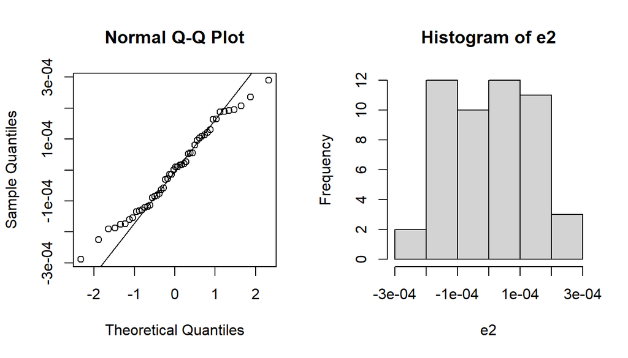

```r
par(mfrow=c(1,2))
qqnorm(e2)
qqline(e2)
hist(e2)
```

```r
rs=rstandard(mod.trans) # internally studentized residuals
sort(rs)
```

```
##           11            4            6           43           34           17
## -2.312397145 -1.642096199 -1.392666838 -1.380232508 -1.299924684 -1.292403731
##           44           22           42           16           23           25
## -1.178380512 -1.127632159 -0.967624764 -0.938663562 -0.931440707 -0.862638779
##            1           45           49            7           27           12
## -0.856274572 -0.851708177 -0.642991480 -0.610231618 -0.585185596 -0.545616584
##           31           36           39           15            9           41
## -0.457293342 -0.408572247 -0.225683154 -0.202064790 -0.107968537 -0.098731576
##           14           46           13           33           32            5
##  0.002777054  0.065610866  0.078390689  0.120827440  0.136776727  0.186842593
##           10           35           20           37           18           29
##  0.200003870  0.378433684  0.390104057  0.409146962  0.602970158  0.687516284
##           50           28           21            2           30           26
##  0.833693070  0.854206385  0.876780085  0.885184531  0.933028492  1.166504902
##            3           48           38           24           47            8
##  1.240330690  1.400678620  1.415709048  1.438322963  1.441925978  1.478156382
##           40           19
##  1.737232362  2.090548516
```

```r
rsd=rstudent(mod.trans) # studentized deleted
sort(rsd)
```

```
##           11            4            6           43           34           17
## -2.435856650 -1.674698690 -1.407777903 -1.394650408 -1.310235780 -1.302362064
##           44           22           42           16           23           25
## -1.183618594 -1.131128046 -0.966925070 -0.937397750 -0.930042275 -0.860141598
##            1           45           49            7           27           12
## -0.853690309 -0.849062901 -0.638748015 -0.605925449 -0.580861352 -0.541313619
##           31           36           39           15            9           41
## -0.453238095 -0.404758491 -0.223287874 -0.199897720 -0.106775978 -0.097638971
##           14           46           13           33           32            5
##  0.002746025  0.064880864  0.077520081  0.119496756  0.135276570  0.184826607
##           10           35           20           37           18           29
##  0.197857079  0.374802119  0.386399132  0.405329966  0.598656145  0.683433153
##           50           28           21            2           30           26
##  0.830818915  0.851594337  0.874485022  0.883015295  0.931658924  1.171316298
##            3           48           38           24           47            8
##  1.247989909  1.416244694  1.432146649  1.456116427  1.459940479  1.498471455
##           40           19
##  1.778494656  2.175531013
```

```r
n=length(e2)
p=4+1 # four predictors + 1
3*p/n # rules of thumb, 3 times the mean leverage value
```

```
## [1] 0.3
```

```r
hv=hatvalues(mod.trans)
sort(hv)
```

```
##         20         14         46         25         36          8         16
## 0.02251734 0.02574946 0.03054924 0.03207145 0.03526037 0.03735911 0.04264019
##         12         26          7         30         27         45         15
## 0.04280306 0.04851763 0.04944598 0.05097477 0.05189556 0.05722013 0.05932553
##         29         31         49         42         19         21         23
## 0.06221607 0.06286777 0.06355888 0.06417731 0.06424817 0.06542733 0.06818938
##         35         48          4         22         33          6         44
## 0.08138412 0.08498652 0.08623296 0.08844258 0.08927508 0.08960146 0.09012184
##         41         17          9         24         10         43         50
## 0.09208789 0.09506497 0.09648760 0.09685602 0.10033898 0.10172016 0.10198735
##         40         13         18         39         38         34         37
## 0.10289140 0.10541465 0.11572004 0.11735640 0.12395238 0.12949804 0.13125063
##          1          3         47         32         11          2         28
## 0.14061825 0.14434012 0.17168830 0.22522744 0.23979244 0.24727915 0.28860921
##          5
## 0.38475924
```

```r
# 0.385 > .3

2*sqrt((p+1)/(n-p-1))
```

```
## [1] 0.7385489
```

```r
diff=dffits(mod.trans) # Difference in Fits (DFFITS)
sort(diff)
```

```
##            11             4            34            43             6
## -1.3680544508 -0.5144647137 -0.5053545527 -0.4693135104 -0.4416476273
##            17            44            22             1            42
## -0.4221174414 -0.3725076355 -0.3523306753 -0.3453250862 -0.2532134711
##            23            45            16            49            25
## -0.2515922280 -0.2091746895 -0.1978317089 -0.1664092449 -0.1565696529
##             7            27            31            12            39
## -0.1381962579 -0.1358968880 -0.1173924079 -0.1144684296 -0.0814190137
##            36            15             9            41            14
## -0.0773809949 -0.0502006076 -0.0348933176 -0.0310958595  0.0004464299
##            46            13            33            20            10
##  0.0115173861  0.0266105475  0.0374134383  0.0586462342  0.0660764923
##            32            35             5            37            29
##  0.0729367020  0.1115590770  0.1461626706  0.1575477328  0.1760337515
##            30            18            21            26            50
##  0.2159214150  0.2165642925  0.2313797959  0.2644987420  0.2799872837
##             8            48            24             2             3
##  0.2951988159  0.4316180200  0.4768490402  0.5061100998  0.5125709942
##            38            28            19            40            47
##  0.5387050822  0.5424175546  0.5700531269  0.6023093405  0.6646738595
```

```r
# no abs val greater than .739

ck=cooks.distance(mod.trans) # Cook's distance measure
sort(ck)
```

```
##           14           46           13           41            9           33
## 4.076583e-08 2.713040e-05 1.448232e-04 1.977429e-04 2.489785e-04 2.862228e-04
##           15           20           10           32           36           39
## 5.150075e-04 7.011306e-04 8.922726e-04 1.087681e-03 1.220238e-03 1.354409e-03
##           35           12           31           27            7            5
## 2.537554e-03 2.662433e-03 2.805737e-03 3.748792e-03 3.874125e-03 4.366422e-03
##           25           37           49           29           16           45
## 4.931320e-03 5.058195e-03 5.612240e-03 6.271852e-03 7.848631e-03 8.805422e-03
##           30           18           21           23           42           26
## 9.351846e-03 9.515693e-03 1.076360e-02 1.269783e-02 1.284198e-02 1.387720e-02
##           50            8            1           22           44           17
## 1.578724e-02 1.695911e-02 2.399450e-02 2.467415e-02 2.750730e-02 3.509373e-02
##           48            6           43           24           34            4
## 3.644429e-02 3.817754e-02 4.314494e-02 4.437235e-02 5.027590e-02 5.089382e-02
##            2            3           38           28           19           40
## 5.148150e-02 5.190281e-02 5.671595e-02 5.920489e-02 6.001373e-02 6.922770e-02
##           47           11
## 8.619118e-02 3.373325e-01
```

```r
#not influential
```

### Interpretation

```r
summary(mod.trans)
```

```
##
## Call:
## lm(formula = y ~ Murder + `HS Grad` + Frost + Population)
##
## Residuals:
##        Min         1Q     Median         3Q        Max
## -2.885e-04 -1.172e-04  4.819e-06  1.082e-04  2.894e-04
##
## Coefficients:
##               Estimate Std. Error t value Pr(>|t|)
## (Intercept)  1.409e-02  1.895e-04  74.366  < 2e-16 ***
## Murder       5.999e-05  7.280e-06   8.241 1.54e-10 ***
## `HS Grad`   -9.329e-06  2.948e-06  -3.164  0.00279 **
## Frost        1.158e-06  4.814e-07   2.406  0.02029 *
## Population  -1.053e-08  4.995e-09  -2.107  0.04068 *
## ---
## Signif. codes:  0 '***' 0.001 '**' 0.01 '*' 0.05 '.' 0.1 ' ' 1
##
## Residual standard error: 0.0001431 on 45 degrees of freedom
## Multiple R-squared:  0.7387, Adjusted R-squared:  0.7155
## F-statistic: 31.81 on 4 and 45 DF,  p-value: 1.352e-12
```

## 5. Conclusion

In conclusion, we are able to predict the meanlife expectancy of people in a U.S. state given its population, local murder rate, high school graduation percentage, and the mean number of days with minimum temperature below freezing. In general, states with higher population and high school graduation percentage would have longer life expectancy, while higher murder rates and more days in freezing temperatures would result in shorter life expectancy.

Given that the size of the dataset is limited (including only statistics from each state), the accuracy could be improved if we are able to draw more data by smaller region, for example, census by county. It would also be helpful if we could draw more possible related predictors into the dataset, for example, the elevation of the region, unemployment rate, healthcare coverage, air quality, etc. We should also note that the data we draw is from the US census in 1977, which means that necessary adjustment is needed with updated data for contemporary prediction.